# Titanic Survivor Data Exploration

Saixiong Han, En Liu, Liping Li

October 20, 2016

## 1. Train Data Processing &Description

> By Liping Li

### -Import and Overview

```r
library(data.table)
train = fread("C:/data/train-titanic.csv", sep = ",", header = TRUE, stringsAsFactors = TRUE)
setkey(train)
summary(train)
```

```
##   PassengerId       Survived          Pclass
##  Min.   :  1.0   Min.   :0.0000   Min.   :1.000
##  1st Qu.:223.5   1st Qu.:0.0000   1st Qu.:2.000
##  Median :446.0   Median :0.0000   Median :3.000
##  Mean   :446.0   Mean   :0.3838   Mean   :2.309
##  3rd Qu.:668.5   3rd Qu.:1.0000   3rd Qu.:3.000
##  Max.   :891.0   Max.   :1.0000   Max.   :3.000
##
##                                     Name         Sex           Age
##  Abbing, Mr. Anthony                  :  1   female:314   Min.   : 0.42
##  Abbott, Mr. Rossmore Edward          :  1   male  :577   1st Qu.:20.12
##  Abbott, Mrs. Stanton (Rosa Hunt)     :  1                Median :28.00
##  Abelson, Mr. Samuel                  :  1                Mean   :29.70
##  Abelson, Mrs. Samuel (Hannah Wizosky):  1                3rd Qu.:38.00
##  Adahl, Mr. Mauritz Nils Martin       :  1                Max.   :80.00
##  (Other)                              :885                NA's   :177
##      SibSp           Parch             Ticket         Fare
##  Min.   :0.000   Min.   :0.0000   1601    :  7   Min.   :  0.00
##  1st Qu.:0.000   1st Qu.:0.0000   347082  :  7   1st Qu.:  7.91
##  Median :0.000   Median :0.0000   CA. 2343:  7   Median : 14.45
##  Mean   :0.523   Mean   :0.3816   3101295 :  6   Mean   : 32.20
##  3rd Qu.:1.000   3rd Qu.:0.0000   347088  :  6   3rd Qu.: 31.00
##  Max.   :8.000   Max.   :6.0000   CA 2144 :  6   Max.   :512.33
##                                   (Other) :852
##          Cabin     Embarked
##             :687    :  2
##  B96 B98    :  4   C:168
##  C23 C25 C27:  4   Q: 77
##  G6         :  4   S:644
##  C22 C26    :  3
##  D          :  3
##  (Other)    :186
```

### -Deal with Age’s NAs

Age has 177 missing values. Cabin has 687 NAs and Embarked has 2. We’ll can put Cabin and Embarked aside. Age is an important demographic variable, so we can try to fill with predictions.

```r
train$Embarked = as.character(train$Embarked)  #change data type that can add NA
train[Embarked == "", `:=`(Embarked, NA)]  #set '' in Embarked as missing value
```

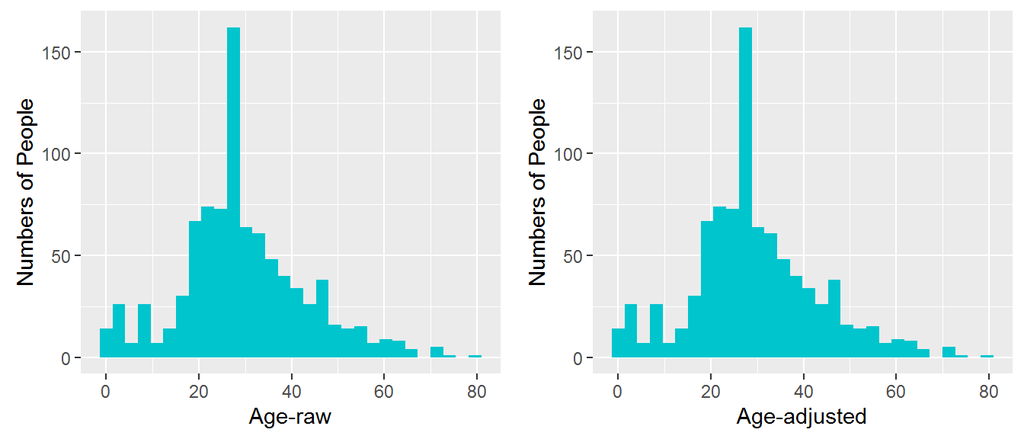

```r
# Tried regression model, R-square is not ideal. So take the tree method.
library(rpart)
library(ggplot2)
library(gridExtra)
age_fit2 = rpart(Age ~ Pclass + Sex + SibSp + Parch + Fare + Embarked, data = train[!is.na(Age),
    ], na.action = na.omit, method = "anova", cp = 0.01)
page1 = qplot(train$Age, geom = "histogram", fill = I("turquoise3"), xlab = "Age-raw",
    ylab = "Numbers of People")
train[is.na(Age), `:=`(Age, predict(age_fit2, newdata = train[is.na(Age)]))]
page2 = qplot(train$Age, geom = "histogram", fill = I("turquoise3"), xlab = "Age-adjusted",
    ylab = "Numbers of People")
grid.arrange(page1, page2, ncol = 2)
```

### -List single variable distribution except Name, Ticket and Cabin

Now, most of variables are factors and numbers. It’s like that you finally pick all the vegetables and meat for dinner. Cannot wait to have a raw view.

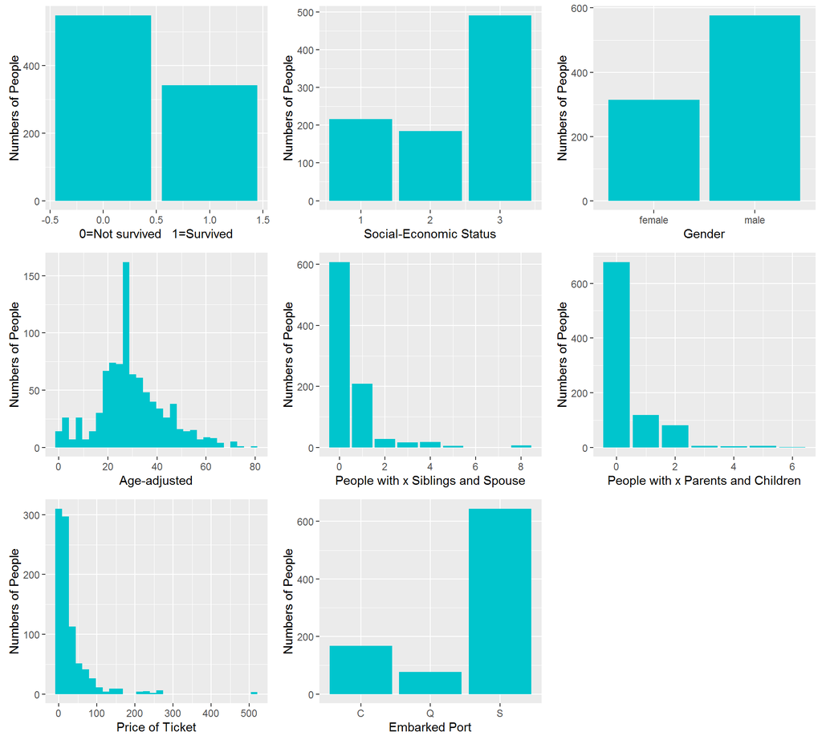

```r
psur = qplot(train$Survived, geom = "bar", ylab = "Numbers of People", fill = I("turquoise3"),
    xlab = "0=Not survived   1=Survived")
ppclass = qplot(train$Pclass, geom = "bar", fill = I("turquoise3"), xlab = "Social-Economic Status",
    ylab = "Numbers of People")
psex = qplot(train$Sex, geom = "bar", fill = I("turquoise3"), xlab = "Gender",
    ylab = "Numbers of People")
pss = qplot(train$SibSp, geom = "bar", xlab = "People with x Siblings and Spouse",
    ylab = "Numbers of People", fill = I("turquoise3"))
ppc = qplot(train$Parch, geom = "bar", xlab = "People with x Parents and Children",
    ylab = "Numbers of People", fill = I("turquoise3"))
pf = qplot(train$Fare, geom = "histogram", fill = I("turquoise3"), xlab = "Price of Ticket",
    ylab = "Numbers of People")
pe = qplot(train$Embarked, xlab = "Embarked Port", fill = I("turquoise3"), ylab = "Numbers of People",
    geom = "bar")
grid.arrange(psur, ppclass, psex, page2, pss, ppc, pf, pe, ncol = 3)
```

Most people are in their golden ages(20~40). Most people are men. Most people are travel alone. Most people from 3rd class. Most people from Southampton. And most of them lost their lives in that adventure.

### -Interesting Thing about Name

Name has many interesting title. Let’s grasp these info.

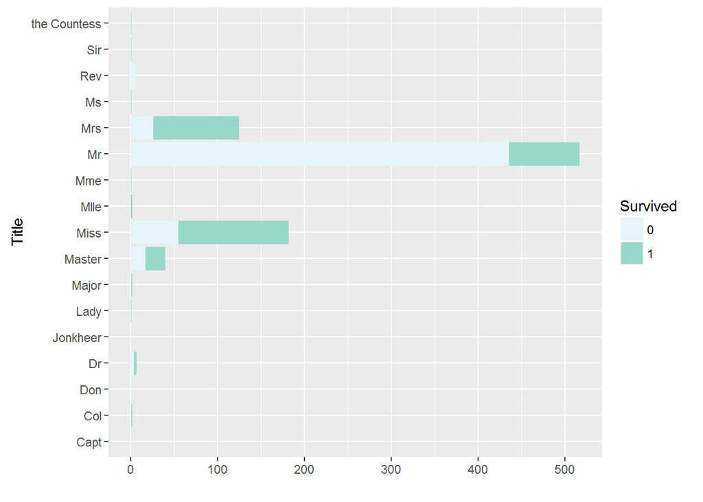

```r
train$Title = gsub("(.*,)|(\\..*)", "", train$Name)
train$Title = as.factor(train$Title)
train$Survived = as.character(train$Survived)
ggplot(train, aes(x = Title, fill = Survived)) + geom_bar() + coord_flip() +
    scale_fill_brewer(palette = "BuGn") + ylab("")
```

The survived “Miss”" is **no** more than married women “Mrs”" in terms of ration. I’ve been heard that people in Titanic give survivor opportunities to unmarried women. But according to this chart, it seems not ture. We’ll dig into it later.

Another phenomenon attracts me is that many people have two names, like “Cumings, Mrs. John Bradley (Florence Briggs Thayer)”. Did they change name before this tragedy or after? We don’t know. Just have a look.

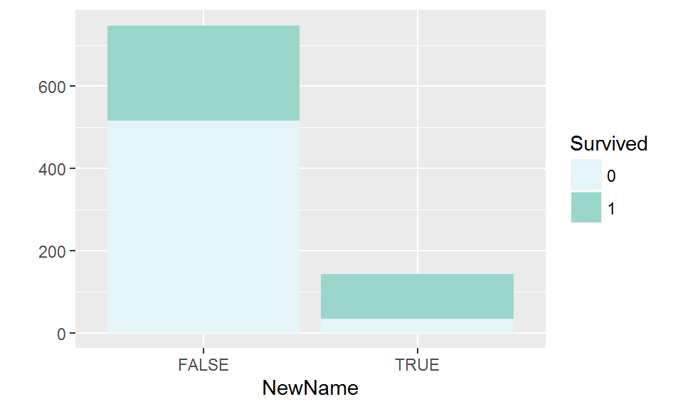

```r
train$NewName = grepl("(", train$Name, fixed = TRUE)
train$Survived = as.character(train$Survived)
ggplot(train, aes(x = NewName, fill = Survived)) + geom_bar() + scale_fill_brewer(palette = "BuGn") +
    ylab("")
```

The ration looks high for people survived to have a second name.

### -A Quick Look of Correlation and Importance

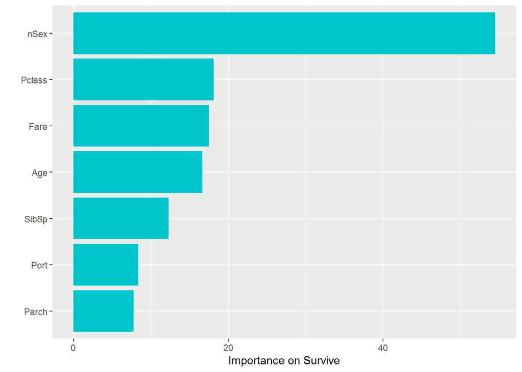

```r
library(GGally)  #Only shows numeric variables
train[Sex == "male", `:=`(nSex, 1)]
train[Sex == "female", `:=`(nSex, 2)]
train[Embarked == "C", `:=`(Port, 1)]
train[Embarked == "Q", `:=`(Port, 2)]
train[Embarked == "S", `:=`(Port, 3)]
train$Survived = as.numeric(train$Survived)
cor = ggcorr(train, label = TRUE, label_alpha = TRUE, name = "Correlation",
    low = "turquoise3", mid = "white", high = "orangered3")

library(randomForest)
rf = randomForest(Survived ~ Pclass + Age + nSex + Parch + SibSp + Fare + Port,
    data = train, na.action = na.omit, ntree = 101, importance = TRUE)
imp = importance(rf, type = 1)
featureImportance = data.frame(Feature = row.names(imp), Importance = imp[,
    1])
ggplot(featureImportance, aes(x = reorder(Feature, Importance), y = Importance)) +
    geom_bar(stat = "identity", fill = I("turquoise3")) + coord_flip() + xlab("") +
    ylab("Importance on Survive")
```

### -X with Survived

Take a close look of every independent variable influence on survive. This time add SibSp and Parch as family size

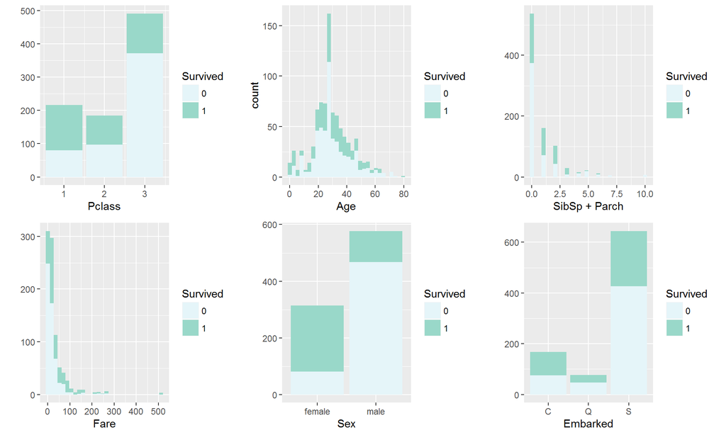

```r
train$Survived = as.character(train$Survived)
SurPc = ggplot(train, aes(x = Pclass, fill = Survived)) + geom_bar() + scale_fill_brewer(palette = "BuGn") +
    ylab("")
Surage = ggplot(train, aes(x = Age, fill = Survived)) + geom_histogram() + scale_fill_brewer(palette = "BuGn")
SurFam = ggplot(train, aes(x = SibSp + Parch, fill = Survived)) + geom_histogram() +
    scale_fill_brewer(palette = "BuGn") + ylab("")
SurFare = ggplot(train, aes(x = Fare, fill = Survived)) + geom_histogram() +
    scale_fill_brewer(palette = "BuGn") + ylab("")
SurSex = ggplot(train, aes(x = Sex, fill = Survived)) + geom_bar() + scale_fill_brewer(palette = "BuGn") +
    ylab("")
SurEmbarked = ggplot(train, aes(x = Embarked, fill = Survived)) + geom_bar() +
    scale_fill_brewer(palette = "BuGn") + ylab("")
grid.arrange(SurPc, Surage, SurFam, SurFare, SurSex, SurEmbarked, ncol = 3)
```

From the diagram, we have a guess: people who are women, young but not too young, have 1-2 companies have more chance to survive.

## 2. Calculate Single Factor Importance in Female Surviving

> Saixiong Han

### -Pclass

```
## , ,  = 0
##
##
##            1   2   3
##   female   3   6  72
##   male    77  91 300
##
## , ,  = 1
##
##
##            1   2   3
##   female  91  70  72
##   male    45  17  47
```

The female survived in the Titanic most from first and second class, the number of female in the first and second class died in Titanic is less than 10. This is a very important factor.

### -Parch

```
## , ,  = 0
##
##
##            0   1   2   3   4   5   6
##   female  41  14  19   1   2   3   1
##   male   404  39  21   1   2   1   0
##
## , ,  = 1
##
##
##            0   1   2   3   4   5   6
##   female 153  46  30   3   0   1   0
##   male    80  19  10   0   0   0   0
```

Women without any children or parents are more likely to survive While the more parch they have, the less probability they can survive.

### -SibSp

```
## , ,  = 0
##
##
##            0   1   2   3   4   5   8
##   female  37  26   3   7   4   1   3
##   male   361  71  12   5  11   4   4
##
## , ,  = 1
##
##
##            0   1   2   3   4   5   8
##   female 137  80  10   4   2   0   0
##   male    73  32   3   0   1   0   0
```

Women without any siblings or spouses are more likely to survive. While the more siblings they have, the less probability they can survive.

### -Title

```
## , ,  = 0
##
##
##           Capt  Col  Don  Dr  Jonkheer  Lady  Major  Master  Miss  Mlle
##   female     0    0    0   0         0     0      0       0    55     0
##   male       1    1    1   4         1     0      1      17     0     0
##
##           Mme  Mr  Mrs  Ms  Rev  Sir  the Countess
##   female    0   0   26   0    0    0             0
##   male      0 436    0   0    6    0             0
##
## , ,  = 1
##
##
##           Capt  Col  Don  Dr  Jonkheer  Lady  Major  Master  Miss  Mlle
##   female     0    0    0   1         0     1      0       0   127     2
##   male       0    1    0   2         0     0      1      23     0     0
##
##           Mme  Mr  Mrs  Ms  Rev  Sir  the Countess
##   female    1   0   99   1    0    0             1
##   male      0  81    0   0    0    1             0
```

The survived unmarried women is more than married women, which is accordance with the result about SibSp. Generally, the number of women survived is more than the women died.

### -Data visualization

#### **Pclass,Survived,Age and Fare Scatter plot**

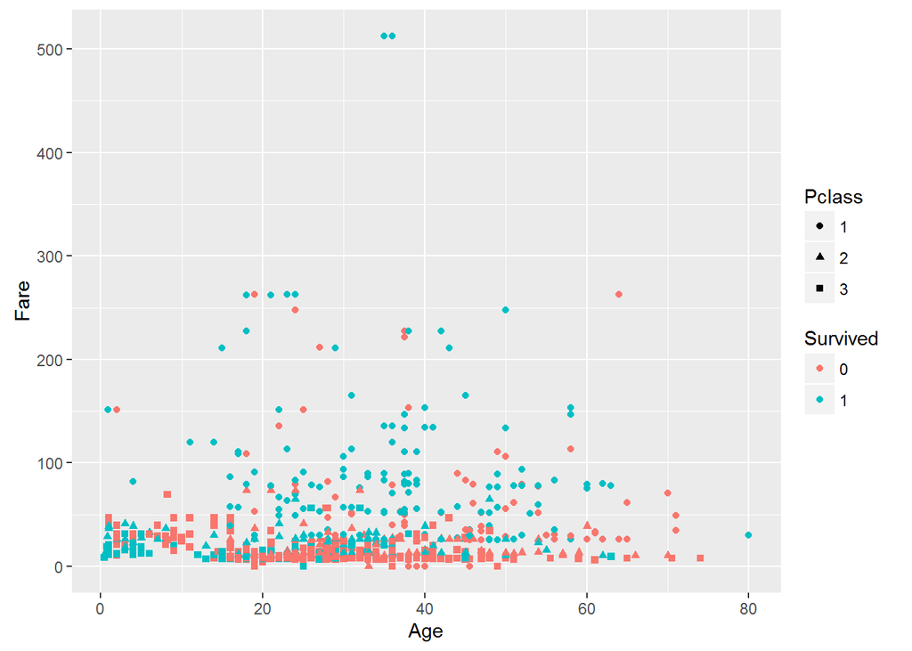

This scatter plot shows there is no linear relation between age and fare. From the color scatter we can see, blue points are mostly on the top wihle the red points are maily on the bottom. That means the higher fare is, the more chances for surviving. It also can be shown in the shape of different classes. The first and second class get more chances for surviving compared to the third class.

#### **Sex,Survived,Age and Fare Sctter plot**

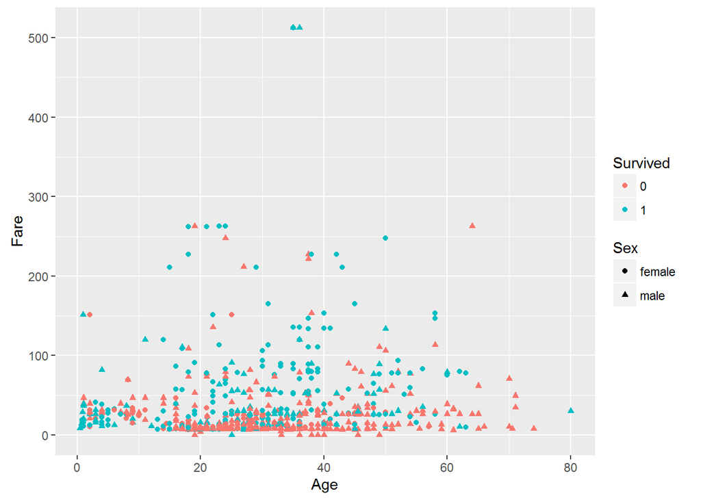

#### **Fare,Sex and Survived(box-plot)**

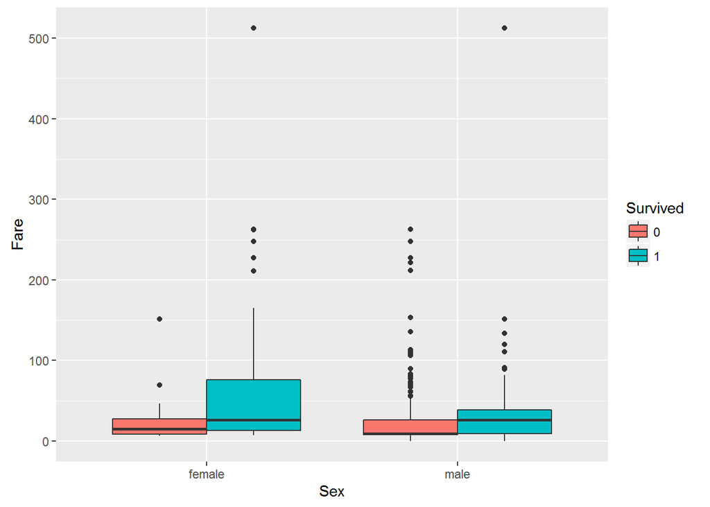

#### **Fare,Pclass and Survived(box-plot)**

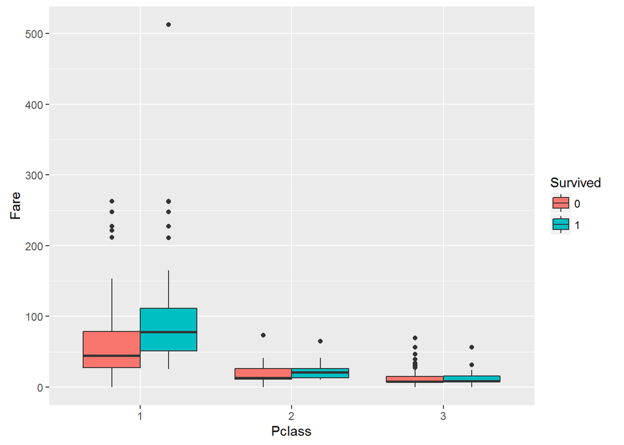

The charts shows that the fare in the first class has larger range than the second and third class. The median of survived people in first class is equal to the upper quartier of dead people. Generally, people in the first class with higher fare have more chance to survive. The upper whisker of second and third class are almost equal to the lower quartier of first class. The fare distribution of second and third class are more intensive than the first class.

#### **Age,Pclass and Survived(violin_plot)**

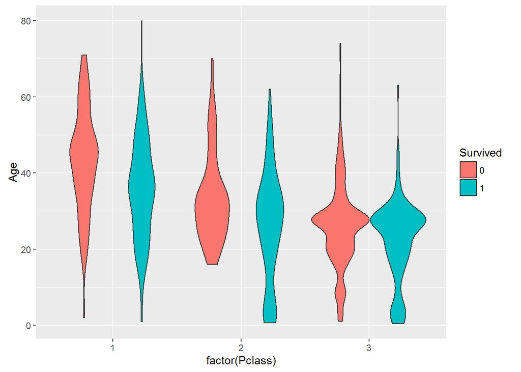

#### **Age,Sex and Survived(violin_plot)**

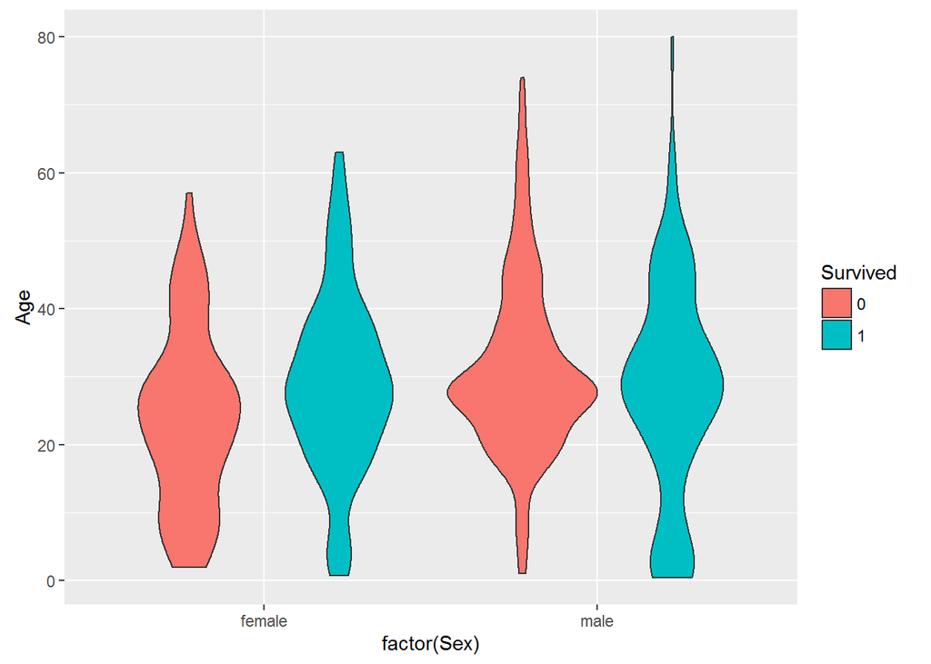

## 3.Analytics of factors

> En Liu

Let’s do some investigation at the influence of age, pclass, and sex to the survival. In order to show the result vividly, we use ggplot2 to draw the facet_grid diagram.

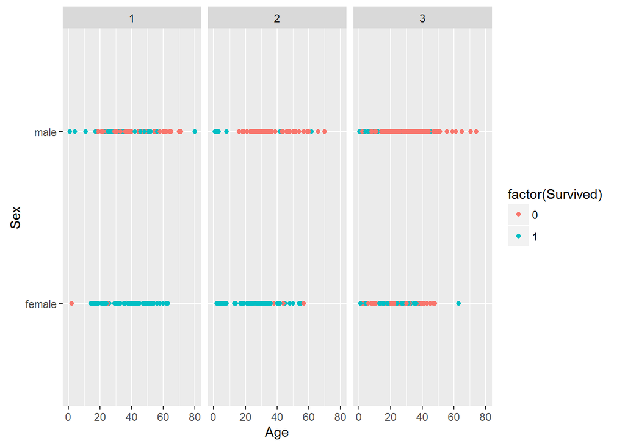

```r
result1 = ggplot(data = train, aes(x = Age, y = Sex, color = factor(Survived)))+geom_point()
result = result1+facet_grid(.~Pclass)
result
```

In this diagram, we can see that age, pclas and sex are all important factors. For those who were in the first class and who were female, there was a bigger chance to survive. We can imagine the scene back then: Titanic was falling, few lifeboats were prepared and young, well-classed ladies and madams were rescued first.For those who landed lifeboats and left, the chance of survival was the biggest.But for those females who were in the third class and the males, things were not so happy. Lifeboats were limited, they must find their own way to make lives. The possiblities of their living can be very small.

Also, we can discuss the relationship between survival and family size. There are no factors called “family size”, but we can conclude from siblings and parch. According to our experience, those who were with babies and old people might have a bigger chance to survive. We can know if we are right from the following diagram.

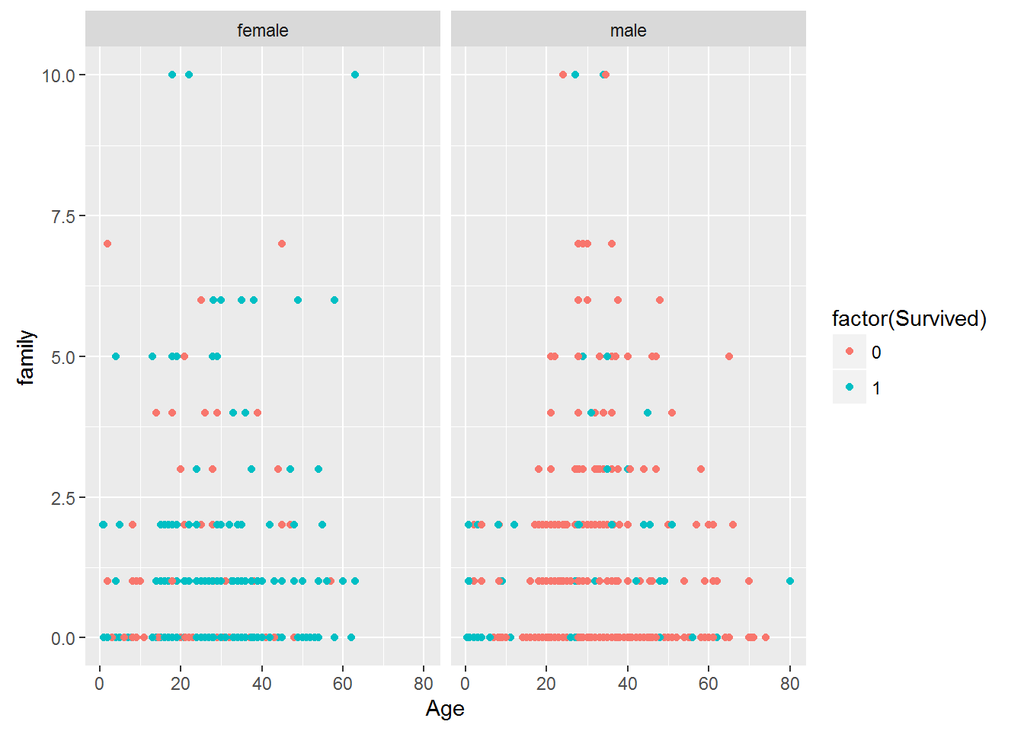

```r
family = train$SibSp+train$Parch
result2 = ggplot(data = train, aes(x = Age, y = family, color = factor(Survived)))+geom_point()
result = result2+facet_grid(.~Sex)
result
```